# Best books by century

Marian Nehrebecki, Aleksander Partyga, Magdalena Sobala

07 June, 2022

## **Century 8**

### Overview

(From the [Goodreads](https://www.goodreads.com)) Goodreads.com is the world’s largest site for readers and book recommendations. The mission of Goodreads is to help people find and share books they love.

The users can rate their favourite books, create lists and share their opinions with their friends. The website also provides extensive information on books from all genres and centuries; it also provides the users with rankings, available by different parameters. The rankings that are of interest to us, are the rating by the century. Below you can find a short summary of each century’s best books.

### A few things we can do on Goodreads

> - See what books our friends are reading.
> - Track the books we are reading, have read, and want to read.
> - Check out our personalized book recommendations. The recommendation engine analyzes 20 billion data points to give suggestions tailored to our literary tastes.
> - Find out if a book is a good fit for us from our community’s reviews.

# Summary of the Best books in Century 8

*Goodreads* provides its users with information on 18 books from **Century 8** that have been published by Author/Authors from **Bede** to **John of Damascus**.

The book can be found under the following link: “https://www.goodreads.com/book/show/379959.Ecclesiastical_History_of_the_English_People”

## Visualisations:

### Books that were rated the most times in Century 8

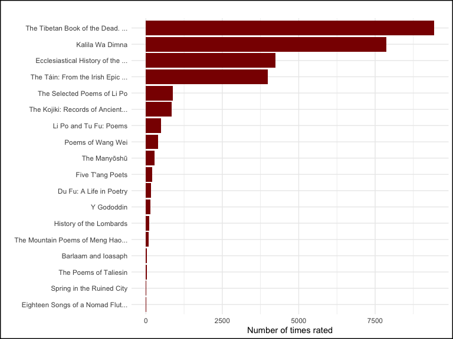

**Summary:**

- The book that was rated the most in Century 8 is **The Tibetan Book of the Dead. First Complete Translation**, and the number of votes is **9434**.
- The average number of voted for a book from Century 8 is equal **1624.1**.

### Books with the highest scores in Century 8

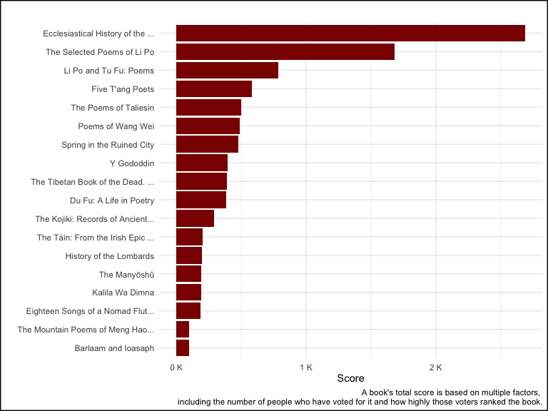

**Summary:**

- The maximum score for a book in Century 8 is **2690** for the book: **Ecclesiastical History of the English People**.
- The average score of all books in Century 8 is **545.6**.
- The minimum score for a book in Century 8 is **98** for the book: **Barlaam and Ioasaph**.

### Most prolific authors in Century 8

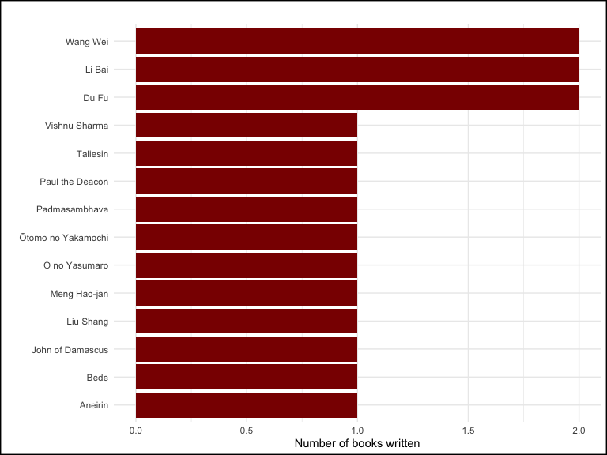

**Summary:**

- The most prolific author in Century 8 is **Li Bai, Wang Wei, Du Fu**.

## List of books with above average rating in Century 8

The number of books with the above average rating in Century 8 is **12** out of all **18** Century 8 books. The below table displays the top 10 results.

| Century | Title | Author | website |
| --- | --- | --- | --- |
| 8th | The Selected Poems of Li Po | Li Bai | https://www.goodreads.com/book/show/5988.The_Selected_Poems_of_Li_Po |
| 8th | Li Po and Tu Fu: Poems | Li Bai | https://www.goodreads.com/book/show/5989.Li_Po_and_Tu_Fu |
| 8th | Five T’ang Poets | Wang Wei | https://www.goodreads.com/book/show/6008.Five_T_ang_Poets |
| 8th | The Poems of Taliesin | Taliesin | https://www.goodreads.com/book/show/17255989-the-poems-of-taliesin |
| 8th | Poems of Wang Wei | Wang Wei | https://www.goodreads.com/book/show/1934248.Poems_of_Wang_Wei |
| 8th | Spring in the Ruined City | Du Fu | https://www.goodreads.com/book/show/7079152-spring-in-the-ruined-city |
| 8th | The Tibetan Book of the Dead. First Complete Translation | Padmasambhava | https://www.goodreads.com/book/show/208123.The_Tibetan_Book_of_the_Dead_First_Complete_Translation |
| 8th | Du Fu: A Life in Poetry | Du Fu | https://www.goodreads.com/book/show/5501213-du-fu |
| 8th | Kalila Wa Dimna | Vishnu Sharma | https://www.goodreads.com/book/show/20907341-kalila-wa-dimna |
| 8th | The Mountain Poems of Meng Hao-jan | Meng Hao-jan | https://www.goodreads.com/book/show/327636.The_Mountain_Poems_of_Meng_Hao_jan |

### References:

https://www.goodreads.com